# Chapter 16 Proportion data | Chapter 17 Binary response variables | Chapter 18 Generalized additive models

# Chapter 18 Generalized Additive Models

Useful when we have no a *priori* reason to choose a particular parametric model.

All error families allowed with `glm` are available, `update` , `predict`, `summary`, `anova` and so on are also available.

- s(x, z) will do isotropic smooth.
- s(x, z) + s(z, w) is allowed for overlapping terms.
- te(x, z, k = 6) (example k) smooths interactions of any number of variables via scale invariant tensor product smooths.
- s(z, bs = “cr”, k = 6) (example) do smoothing with cubic regression spline(cr), while the default is “tp”.

**Technical aspects**:

- The degree of smoothness of model terms is estimated as part of the fitting
- Isotropic or scale-invariant smooths of any number of variables are available as model terms
- Confidence or credible intervals are readily available for any quantity predicted using a fitted model
- In `mgcv`, `gam` solves the smoothing parameter estimation by using
1. the generalized cross validation(GCV): $GCV = \frac{nD}{(n - d.f.)^2}$.
2. unbiased risk estimator(UBRE) when $\phi$ is known: $UBRE = \frac{D}{n} + 2\phi \frac{d.f.}{n} - \phi$.

See `?gam.method` for more details.

## Non-parametric smoothers

- `loess`
- `tree`

```r
soay <- read.table("soaysheep.txt", header = TRUE)
attach(soay)
names(soay)
```

```
## [1] "Year"       "Population" "Delta"
```

```r
# Delta is the yearly change, population is the density


plot(Population, Delta, pch = 21, col = "green", bg = "red")

model <- loess(Delta ~ Population)
# loess : Fit a polynomial surface determined by one or more numerical predictors, using local fitting.

summary(model)
```

```
## Call:
## loess(formula = Delta ~ Population)
##
## Number of Observations: 44
## Equivalent Number of Parameters: 4.66
## Residual Standard Error: 0.2616
## Trace of smoother matrix: 5.11  (exact)
##
## Control settings:
##   span     :  0.75
##   degree   :  2
##   family   :  gaussian
##   surface  :  interpolate      cell = 0.2
##   normalize:  TRUE
##  parametric:  FALSE
## drop.square:  FALSE
```

```r
# draw smoothed line
xv <- seq(600, 2000, 1)
yv <- predict(model, data.frame(Population = xv))
lines(xv, yv, col = "red") # looks like a step function

rm(xv, yv)


# use tree to determine the threshold for splitting the data into low and high density parts
library(tree)
thresh <- tree(Delta ~ Population)
print(thresh)
```

```
## node), split, n, deviance, yval
##       * denotes terminal node
##
##  1) root 44 5.2870  0.006208
##    2) Population < 1289.5 25 0.8596  0.226500
##      4) Population < 1009.5 13 0.2364  0.277600 *
##      5) Population > 1009.5 12 0.5525  0.171200
##       10) Population < 1059.5 5 0.1631  0.072120 *
##       11) Population > 1059.5 7 0.3053  0.241900 *
##    3) Population > 1289.5 19 1.6180 -0.283700
##      6) Population < 1459 9 0.7917 -0.349500 *
##      7) Population > 1459 10 0.7519 -0.224400 *
```

```r
# plot(thresh)

th <- 1289.5 # threshold


model2 <- aov(Delta ~ (Population > th))
summary(model2)
```

```
##                 Df Sum Sq Mean Sq F value   Pr(>F)
## Population > th  1  2.810   2.810   47.63 2.01e-08 ***
## Residuals       42  2.477   0.059
## ---
## Signif. codes:  0 '***' 0.001 '**' 0.01 '*' 0.05 '.' 0.1 ' ' 1
## 1 observation deleted due to missingness
```

```r
tail(Delta, 2) # the 45th data is NA , remove it
```

```
## [1] -0.7463679         NA
```

```r
tapply(Delta[-45], (Population[-45] > th), mean)
```

```
##      FALSE       TRUE
##  0.2265084 -0.2836616
```

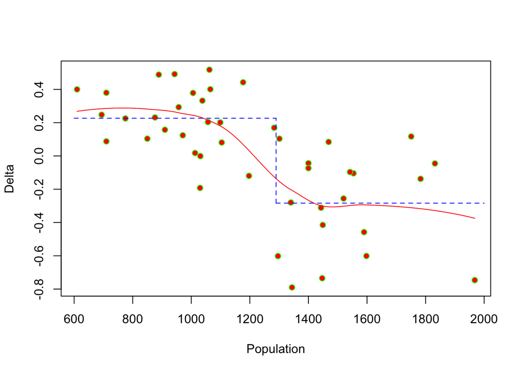

```r
# add step functions
lines(c(600, th), c(0.2265, 0.2265), lty = 2, col = "blue")
lines(c(th, 2000), c(-0.2837, -0.2837), lty = 2, col = "blue")
lines(c(th, th), c(-0.2837, 0.2265), lty = 2, col = "blue")
```

```r
# Three parameters (two averages and a threshold) in step function,
# 4.66 df for loess,
# parsimony favours the step function
detach(soay)
```

## Generalized additive models

`gam` is used.

```r
ozone.data <- read.table("ozone.data.txt", header = TRUE)
attach(ozone.data)
names(ozone.data)
```

```
## [1] "rad"   "temp"  "wind"  "ozone"
```

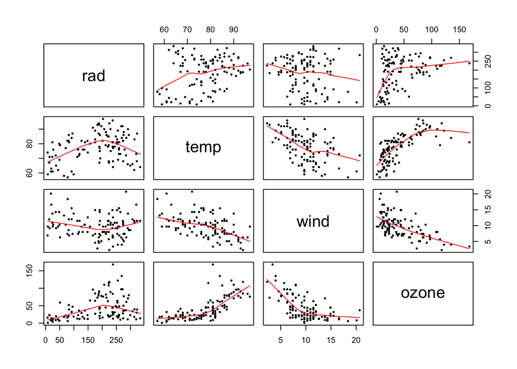

```r
# ozone is y , the other three are continuous variables


# inspect the data with non parametric loess
pairs(ozone.data, panel = function(x, y) {points(x, y, pch = 16, cex = 0.6); lines(lowess(x, y), col = "red")} )
```

```r
# fit all variables with non parametric smoothers s()
# s() does not evaluate a (spline) smooth - it exists purely to help set up a model using spline based smooths.

model <- gam(ozone ~ s(rad) + s(temp) + s(wind))
summary(model)
```

```
##
## Family: gaussian
## Link function: identity
##
## Formula:
## ozone ~ s(rad) + s(temp) + s(wind)
##
## Parametric coefficients:
##             Estimate Std. Error t value Pr(>|t|)
## (Intercept)    42.10       1.66   25.36   <2e-16 ***
## ---
## Signif. codes:  0 '***' 0.001 '**' 0.01 '*' 0.05 '.' 0.1 ' ' 1
##
## Approximate significance of smooth terms:
##           edf Ref.df      F  p-value
## s(rad)  2.763  3.451  3.964   0.0085 **
## s(temp) 3.841  4.762 11.612 8.19e-09 ***
## s(wind) 2.918  3.666 13.770 1.39e-08 ***
## ---
## Signif. codes:  0 '***' 0.001 '**' 0.01 '*' 0.05 '.' 0.1 ' ' 1
##
## R-sq.(adj) =  0.724   Deviance explained = 74.8%
## GCV =    338  Scale est. = 305.96    n = 111
```

```r
# add interaction term using update
model2 <- update(model, ~ . + s(wind, temp))
summary(model2)
```

```
##
## Family: gaussian
## Link function: identity
##
## Formula:
## ozone ~ s(rad) + s(temp) + s(wind) + s(wind, temp)
##
## Parametric coefficients:
##             Estimate Std. Error t value Pr(>|t|)
## (Intercept)   42.099      1.361   30.92   <2e-16 ***
## ---
## Signif. codes:  0 '***' 0.001 '**' 0.01 '*' 0.05 '.' 0.1 ' ' 1
##
## Approximate significance of smooth terms:
##                 edf Ref.df     F p-value
## s(rad)        1.389  1.667 5.799  0.0126 *
## s(temp)       1.000  1.000 0.000  0.9892
## s(wind)       5.613  6.482 2.492  0.0244 *
## s(wind,temp) 18.246 27.000 2.805 8.5e-08 ***
## ---
## Signif. codes:  0 '***' 0.001 '**' 0.01 '*' 0.05 '.' 0.1 ' ' 1
##
## R-sq.(adj) =  0.814   Deviance explained = 85.9%
## GCV = 272.66  Scale est. = 205.72    n = 111
```

```r
# write out the model
model3 <- gam(ozone ~ s(temp) + s(wind) + s(rad) + s(wind,temp))
summary(model3)
```

```
##
## Family: gaussian
## Link function: identity
##
## Formula:
## ozone ~ s(temp) + s(wind) + s(rad) + s(wind, temp)
##
## Parametric coefficients:
##             Estimate Std. Error t value Pr(>|t|)
## (Intercept)   42.099      1.361   30.92   <2e-16 ***
## ---
## Signif. codes:  0 '***' 0.001 '**' 0.01 '*' 0.05 '.' 0.1 ' ' 1
##
## Approximate significance of smooth terms:
##                 edf Ref.df     F p-value
## s(temp)       1.000  1.000 0.000  0.9892
## s(wind)       5.613  6.482 2.492  0.0244 *
## s(rad)        1.389  1.667 5.799  0.0126 *
## s(wind,temp) 18.246 27.000 2.805 8.5e-08 ***
## ---
## Signif. codes:  0 '***' 0.001 '**' 0.01 '*' 0.05 '.' 0.1 ' ' 1
##
## R-sq.(adj) =  0.814   Deviance explained = 85.9%
## GCV = 272.66  Scale est. = 205.72    n = 111
```

```r
anova(model2, model3) # these two models should be the same
```

```
## Analysis of Deviance Table
##
## Model 1: ozone ~ s(rad) + s(temp) + s(wind) + s(wind, temp)
## Model 2: ozone ~ s(temp) + s(wind) + s(rad) + s(wind, temp)
##   Resid. Df Resid. Dev       Df   Deviance
## 1    78.791      17230
## 2    78.791      17230 1.62e-12 6.5484e-11
```

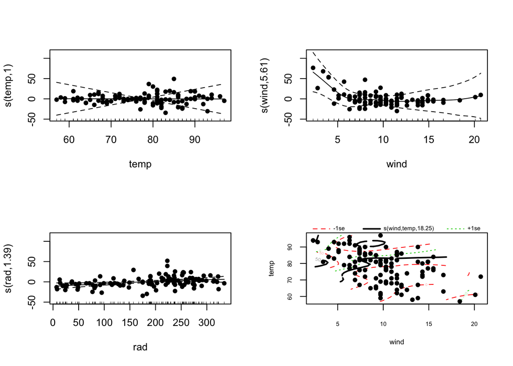

```r
par(mfrow=c(2, 2))
plot(model3, residuals = TRUE, pch = 16)
```

```r
par(mfrow = c(1, 1))

detach(ozone.data)
```

## An example with strongly humped data

```r
# install.packages("SemiPar")
library(SemiPar)
data(ethanol)
attach(ethanol)
head(ethanol)
```

```
##     NOx  C     E
## 1 3.741 12 0.907
## 2 2.295 12 0.761
## 3 1.498 12 1.108
## 4 2.881 12 1.016
## 5 0.760 12 1.189
## 6 3.120  9 1.001
```

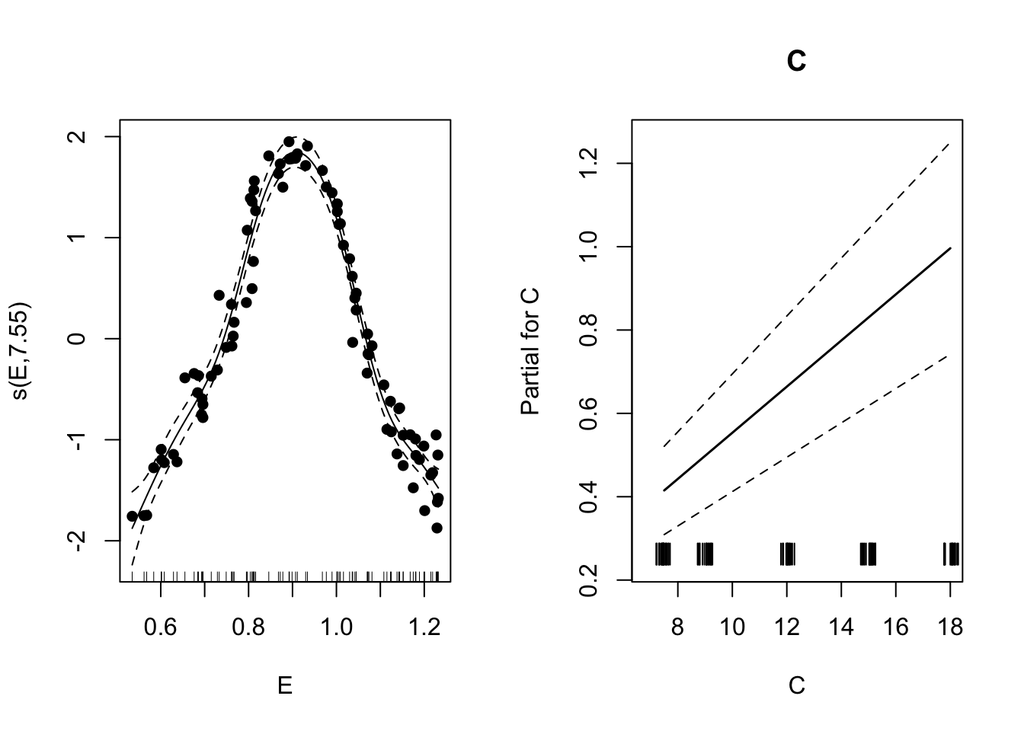

```r
# NOx is y

# fit E as smoothed term and C as parametric term
model <- gam(NOx ~ s(E) + C)

par(mfrow=c(1,2))
plot.gam(model, residuals = T, pch = 16, all.terms = T)
```

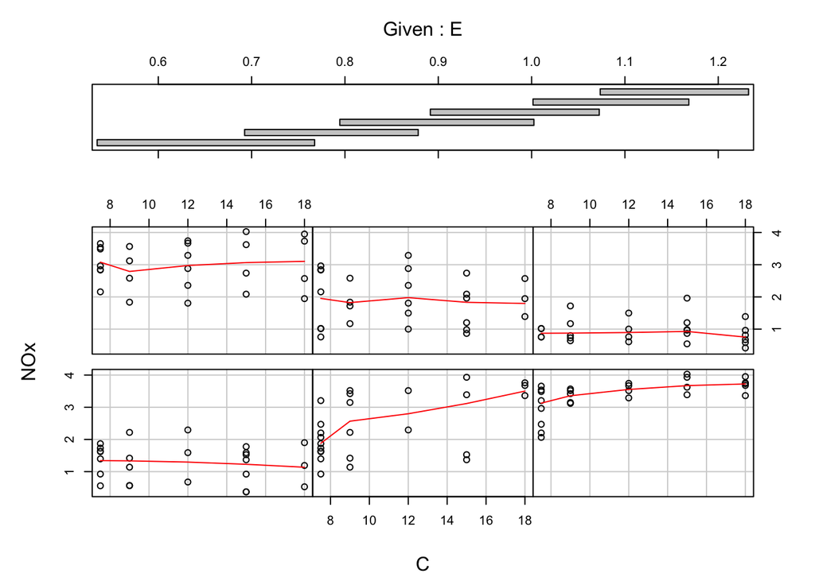

```r
coplot(NOx ~ C | E, panel = panel.smooth) # only panel 2 has a pronounced effect
```

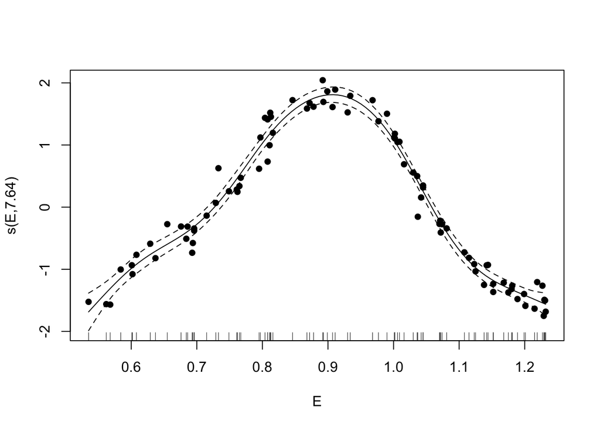

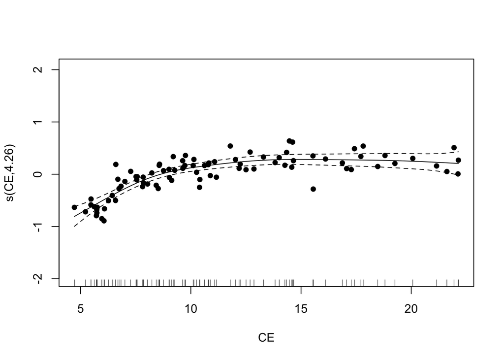

```r
par(mfrow = c(1, 1))


# add interaction term without C
CE <- E * C
model2 <- gam(NOx ~ s(E) + s(CE))


plot.gam(model2, residuals = TRUE, pch = 16, all.terms = T)
```

```r
summary(model2) # significant
```

```
##
## Family: gaussian
## Link function: identity
##
## Formula:
## NOx ~ s(E) + s(CE)
##
## Parametric coefficients:
##             Estimate Std. Error t value Pr(>|t|)
## (Intercept)  1.95737    0.02126   92.07   <2e-16 ***
## ---
## Signif. codes:  0 '***' 0.001 '**' 0.01 '*' 0.05 '.' 0.1 ' ' 1
##
## Approximate significance of smooth terms:
##         edf Ref.df      F p-value
## s(E)  7.636  8.509 270.17  <2e-16 ***
## s(CE) 4.261  5.224  25.25  <2e-16 ***
## ---
## Signif. codes:  0 '***' 0.001 '**' 0.01 '*' 0.05 '.' 0.1 ' ' 1
##
## R-sq.(adj) =  0.969   Deviance explained = 97.3%
## GCV = 0.0466  Scale est. = 0.039771  n = 88
```

```r
detach(ethanol)
```

## Generalized additive models with binary data

```r
attach(island)
names(island)
```

```
## [1] "incidence" "area"      "isolation"
```

```r
model3 <- gam(incidence ~ s(area) + s(isolation), family = binomial)
summary(model3) # area not significant
```

```
##
## Family: binomial
## Link function: logit
##
## Formula:
## incidence ~ s(area) + s(isolation)
##
## Parametric coefficients:
##             Estimate Std. Error z value Pr(>|z|)
## (Intercept)   1.6371     0.9898   1.654   0.0981 .
## ---
## Signif. codes:  0 '***' 0.001 '**' 0.01 '*' 0.05 '.' 0.1 ' ' 1
##
## Approximate significance of smooth terms:
##                edf Ref.df Chi.sq p-value
## s(area)      2.429  3.066  3.455 0.32945
## s(isolation) 1.000  1.000  7.480 0.00624 **
## ---
## Signif. codes:  0 '***' 0.001 '**' 0.01 '*' 0.05 '.' 0.1 ' ' 1
##
## R-sq.(adj) =   0.63   Deviance explained = 63.1%
## UBRE = -0.32096  Scale est. = 1         n = 50
```

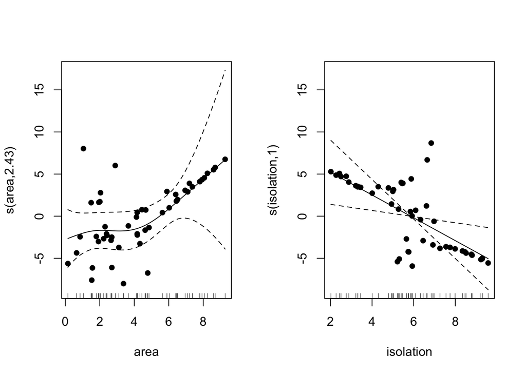

```r
par(mfrow=c(1, 2))
plot.gam(model3, residuals = TRUE, pch = 16)
```

```r
# fit isolation alone
model4 <- gam(incidence ~ s(isolation), family = binomial)
anova(model3, model4, test = "Chisq") # model3 preferred
```

```
## Analysis of Deviance Table
##
## Model 1: incidence ~ s(area) + s(isolation)
## Model 2: incidence ~ s(isolation)
##   Resid. Df Resid. Dev       Df Deviance Pr(>Chi)
## 1    44.934     25.094
## 2    45.191     29.127 -0.25709   -4.033 0.007425 **
## ---
## Signif. codes:  0 '***' 0.001 '**' 0.01 '*' 0.05 '.' 0.1 ' ' 1
```

```r
# fit area as parameteric term
model5 <- gam(incidence ~ area + s(isolation), family = binomial)
summary(model5) # significant
```

```
##
## Family: binomial
## Link function: logit
##
## Formula:
## incidence ~ area + s(isolation)
##
## Parametric coefficients:
##             Estimate Std. Error z value Pr(>|z|)
## (Intercept)  -1.3928     0.9002  -1.547   0.1218
## area          0.5807     0.2478   2.344   0.0191 *
## ---
## Signif. codes:  0 '***' 0.001 '**' 0.01 '*' 0.05 '.' 0.1 ' ' 1
##
## Approximate significance of smooth terms:
##              edf Ref.df Chi.sq p-value
## s(isolation)   1      1  8.276 0.00402 **
## ---
## Signif. codes:  0 '***' 0.001 '**' 0.01 '*' 0.05 '.' 0.1 ' ' 1
##
## R-sq.(adj) =  0.597   Deviance explained = 58.3%
## UBRE = -0.31196  Scale est. = 1         n = 50
```

```r
detach(island)
```

**Summary**: a term can appear to be significant when entered as a parametric term but not when as a non-parametric term.

## Three-dimensional graphic output from `gam`

`vis.gam` is used when there are two continuous explanatory variables. It produces perspective or contour plot views of gam model predictions, fixing all but the values in view to the values supplied in cond.

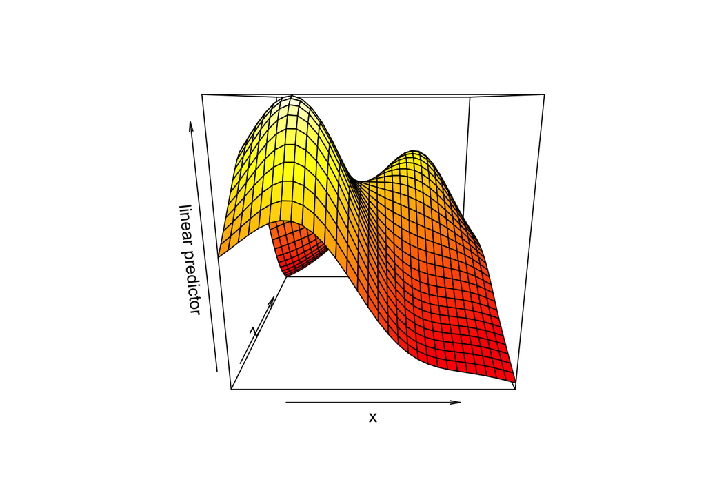

```r
test1 <- function(x, z, sx = 0.3, sz = 0.4) {
  (pi**sx*sz) * (1.2 * exp(- (x - 0.2)^2/sx^2 - (z - 0.3)^2/sz^2) +
                  0.8*exp(- (x - 0.7)^2/sx^2 - (z - 0.8)^2/sz^2))
}


n <- 500
x <- runif(n); z <- runif(n); # random variables from unif(0, 1)
y <- test1(x, z) + rnorm(n) * 0.1
b4 <- gam(y ~ s(x, z))
vis.gam(b4)
```

```r
# z axis is the linear predictor
```